# Tugas 67 MPDW

Azzahra Adelia Putri

2023-10-16

## Pemanggilan Packages

```r
library(ggplot2)
library(tsibble)
library(tseries)
library(MASS)
library(forecast)
library(TSA)
library(TTR)
library(aTSA)
library(graphics)
library(readxl)
```

## Impor Data

```r
data <- read_excel("C:/Users/Asus/Downloads/data suhu palembang.xlsx", sheet=2)
head(data)
```

```
## # A tibble: 6 × 2
##   date                 temp
##   <dttm>              <dbl>
## 1 2021-04-11 00:00:00  28.2
## 2 2021-04-12 00:00:00  28.2
## 3 2021-04-13 00:00:00  28.4
## 4 2021-04-14 00:00:00  28.3
## 5 2021-04-15 00:00:00  28.1
## 6 2021-04-16 00:00:00  28.1
```

### Ubah ke data Time Series

```r
data.ts <- ts(data$temp)
```

### Plot Time Series

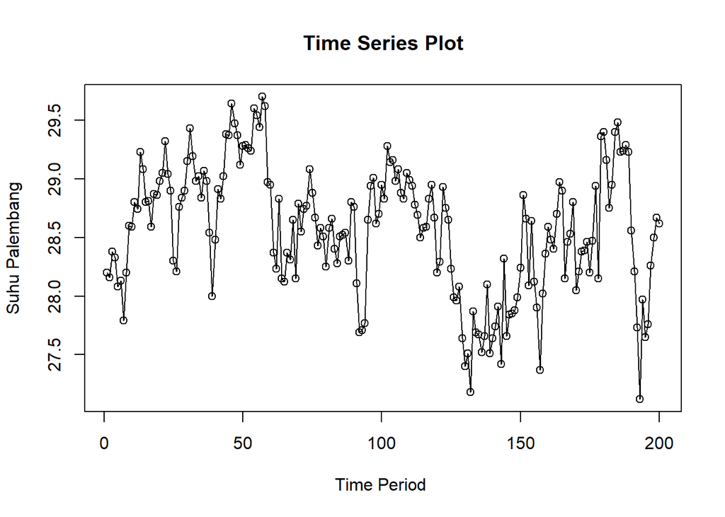

```r
ts.plot(data.ts, xlab="Time Period ", ylab="Suhu Palembang",
        main = "Time Series Plot")
points(data.ts)
```

### Plot Data Latih

```r
data.train <- data.ts[1:126]
head(data.train)
```

```
## [1] 28.20 28.16 28.38 28.33 28.08 28.13
```

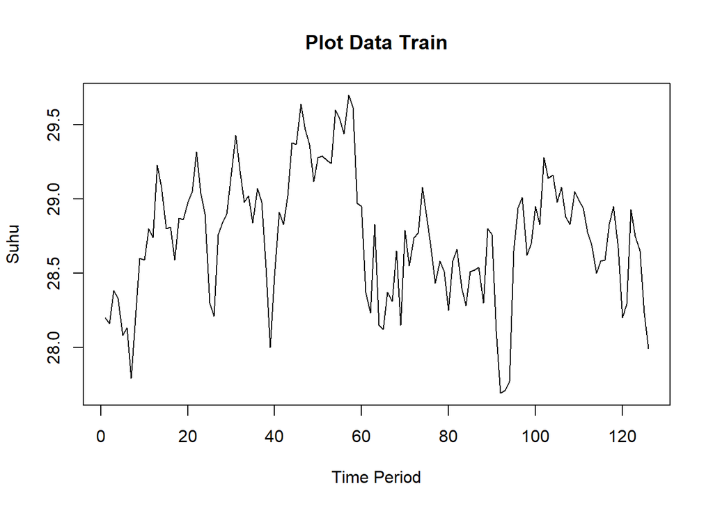

```r
plot.ts(data.train, lty=1, xlab="Time Period", ylab="Suhu", main="Plot Data Train")
```

Berdasarkan plot data train deret waktu di atas menunjukkan bahwa data tidak stasioner dalam rataan, ditandai dengan data yang tidak menyebar di sekitar nilai tengahnya.

### Plot Data Uji

```r
data.test <- data.ts[127:200]
head(data.test)
```

```
## [1] 27.96 28.08 27.64 27.40 27.51 27.18
```

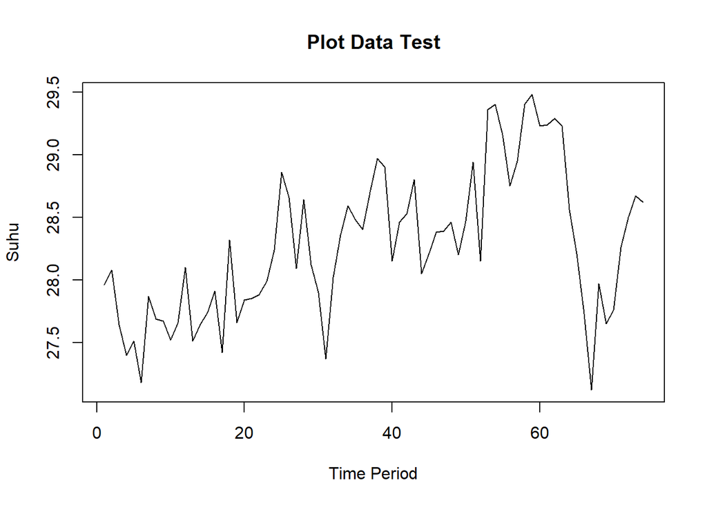

```r
plot.ts(data.test, lty=1, xlab="Time Period", ylab="Suhu", main="Plot Data Test")
```

Berdasarkan plot data test deret waktu di atas menunjukkan bahwa data tidak stasioner dalam rataan, ditandai dengan data yang tidak menyebar di sekitar nilai tengahnya.

## Uji Stasioneritas Data

### Plot ACF

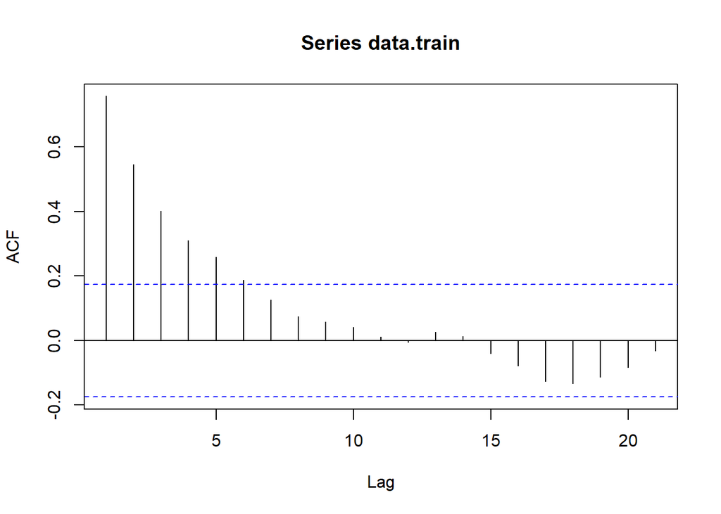

```r
acf(data.train)
```

Berdasarkan plot ACF, terlihat bahwa plot ACF data menurun secara perlahan (tails of slowly). Hal ini juga menjadi indikasi bahwa data tidak stasioner dalam rataan.

### Uji ADF

```r
tseries::adf.test(data.train)
```

```
##
##  Augmented Dickey-Fuller Test
##
## data:  data.train
## Dickey-Fuller = -3.2994, Lag order = 4, p-value = 0.07454
## alternative hypothesis: stationary
```

$H_0$ : Data tidak stasioner dalam rataan

$H_1$ : Data stasioner dalam rataan

Berdasarkan uji ADF tersebut, didapat *p-value* sebesar 0.07454 yang lebih besar dari taraf nyata 5% dan menandakan bahwa data tidak stasioner dalam rataan. Hal ini sesuai dengan hasil eksplorasi menggunakan plot time series dan plot ACF

### Plot Box-Cox

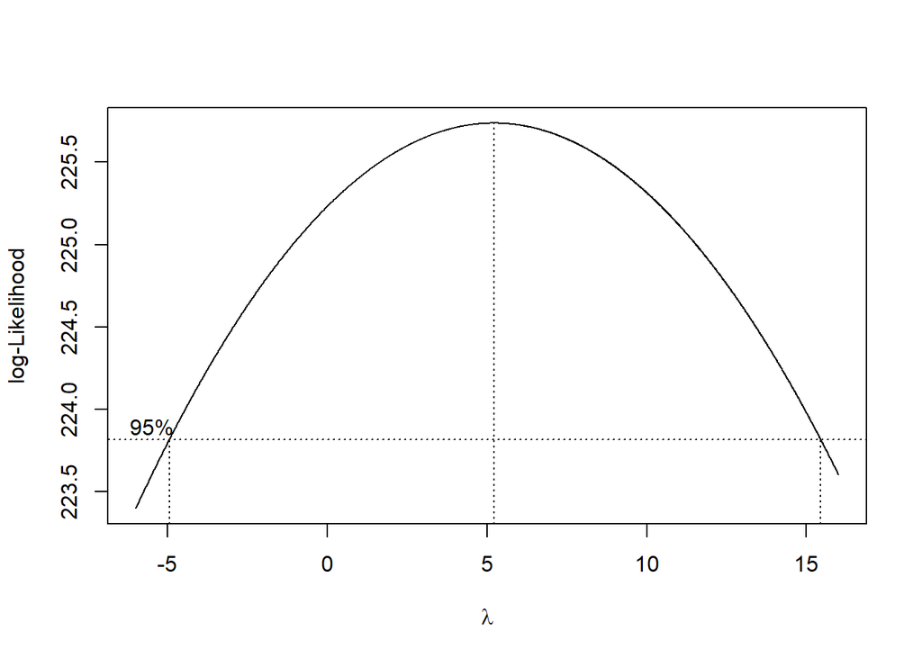

```r
index <- seq(1:126)
bc = boxcox(data.train~index, lambda = seq(-6,16,by=0.01))
```

```r
#Nilai Rounded Lambda
lambda <- bc$x[which.max(bc$y)]
lambda
```

```
## [1] 5.21
```

```r
#SK
bc$x[bc$y > max(bc$y) - 1/2 * qchisq(.95,1)]
```

[output not shown]

[output cut: 155 more lines]

Kesimpulan : Stasioner dalam Ragam, Tidak Stasioner dalam Rataan

## Penanganan Ketidakstasioneran Data

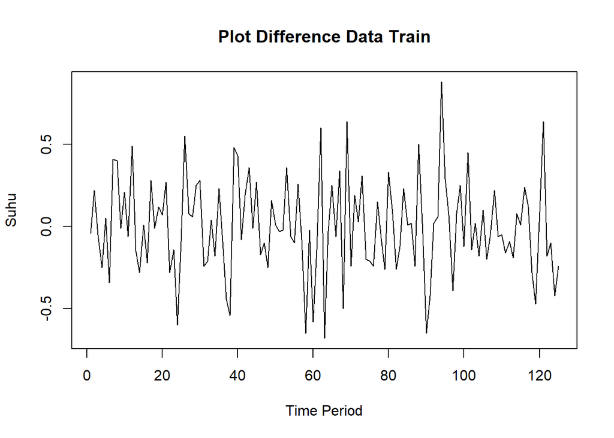

```r
train.diff <- diff(data.train,differences = 1)
plot.ts(train.diff, lty=1, xlab="Time Period", ylab="Suhu", main="Plot Difference Data Train")
```

Berdasarkan plot data deret waktu, terlihat bahwa data sudah stasioner dalam rataan ditandai dengan data bergerak pada nilai tengah tertentu (tidak terdapat trend ataupun musiman pada data).

### Plot ACF

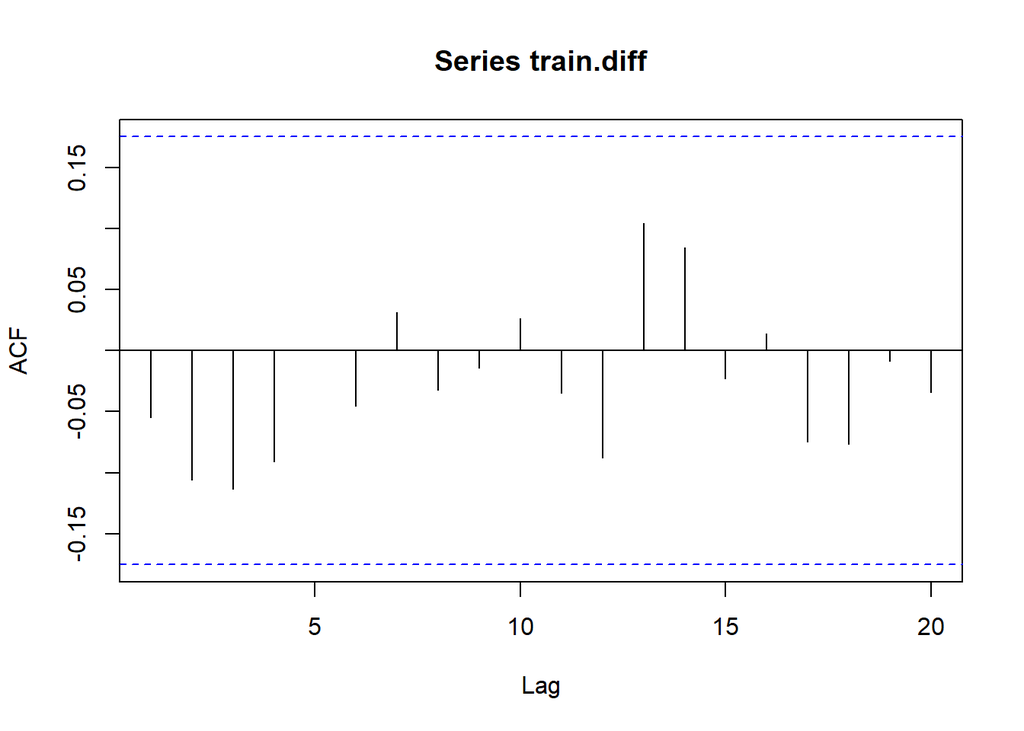

```r
acf(train.diff)
```

Berdasarkan plot ACF, terlihat bahwa plot ACF pada data tersebut cenderung *tails off* dan membentuk gelombang sinus.Hal ini menandakan data sudah stasioner dalam rataan dan ketidakstasioneran data telah berhasil tertangani.

### Uji ADF

```r
tseries::adf.test(train.diff)
```

```
##
##  Augmented Dickey-Fuller Test
##
## data:  train.diff
## Dickey-Fuller = -6.1796, Lag order = 4, p-value = 0.01
## alternative hypothesis: stationary
```

$H_0$ : Data tidak stasioner dalam rataan

$H_1$ : Data stasioner dalam rataan

Berdasarkan uji ADF tersebut, didapat *p-value* sebesar 0.01 yang lebih kecil dari taraf nyata 5% dan menandakan bahwa data stasioner dalam rataan. Hal ini sesuai dengan hasil eksplorasi menggunakan plot time series dan plot ACF

## Identifikasi Model

### Plot ACF

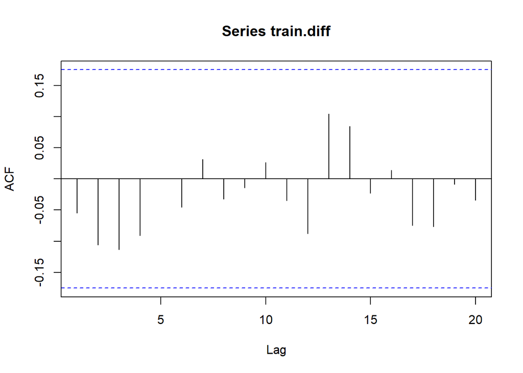

```r
acf (train.diff)
```

### Plot PACF

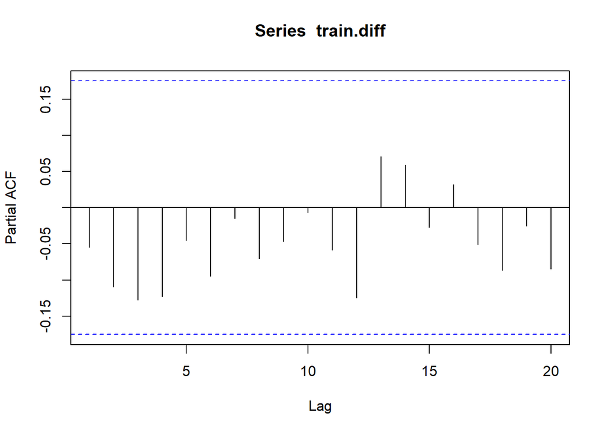

```r
pacf(train.diff)
```

### Plot EACF

```r
eacf(train.diff)
```

```
## AR/MA
##   0 1 2 3 4 5 6 7 8 9 10 11 12 13
## 0 o o o o o o o o o o o  o  o  o
## 1 x o o o o o o o o o o  o  o  o
## 2 x o o o o o o o o o o  o  o  o
## 3 x o o o o o o o o o o  o  o  o
## 4 x x o o o o o o o o o  o  o  o
## 5 x x o o o o o o o o o  o  o  o
## 6 o x o o x o o o o o o  o  o  o
## 7 x x x o o o o o o o o  o  o  o
```

Identifikasi model menggunakan plot EACF dilakukan dengan melihat ujung segitiga pada pola segitiga nol. Dalam hal ini model tentatif yang terbentuk adalah ARIMA(1,1,1), ARIMA(2,1,1), dan ARIMA(3,1,1)

## Pendugaan Parameter Model Tentatif

### ARIMA(1,1,1)

```r
model1.da=Arima(train.diff, order=c(1,1,1),method="ML")
summary(model1.da) #AIC=55.27
```

```
## Series: train.diff
## ARIMA(1,1,1)
##
## Coefficients:
##           ar1      ma1
##       -0.0472  -1.0000
## s.e.   0.0899   0.0249
##
## sigma^2 = 0.08509:  log likelihood = -24.63
## AIC=55.27   AICc=55.47   BIC=63.73
##
## Training set error measures:
##                       ME      RMSE      MAE      MPE     MAPE      MASE
## Training set -0.01648626 0.2881867 0.224098 102.9977 111.5068 0.6544549
##                    ACF1
## Training set -0.0142061
```

```r
lmtest::coeftest(model1.da)
```

```
##
## z test of coefficients:
##
##      Estimate Std. Error  z value Pr(>|z|)
## ar1 -0.047181   0.089895  -0.5248   0.5997
## ma1 -1.000000   0.024898 -40.1644   <2e-16 ***
## ---
## Signif. codes:  0 '***' 0.001 '**' 0.01 '*' 0.05 '.' 0.1 ' ' 1
```

### ARIMA(2,1,1)

```r
model2.da=Arima(train.diff, order=c(2,1,1),method="ML")
summary(model2.da) #AIC=55.94
```

```
## Series: train.diff
## ARIMA(2,1,1)
##
## Coefficients:
##           ar1      ar2      ma1
##       -0.0547  -0.1041  -1.0000
## s.e.   0.0896   0.0901   0.0259
##
## sigma^2 = 0.08473:  log likelihood = -23.97
## AIC=55.94   AICc=56.28   BIC=67.22
##
## Training set error measures:
##                       ME      RMSE       MAE      MPE     MAPE      MASE
## Training set -0.01725042 0.2863961 0.2231172 90.17122 116.1255 0.6515905
##                     ACF1
## Training set -0.02254652
```

```r
lmtest::coeftest(model2.da)
```

```
##
## z test of coefficients:
##
##      Estimate Std. Error  z value Pr(>|z|)
## ar1 -0.054694   0.089569  -0.6106   0.5414
## ar2 -0.104077   0.090105  -1.1551   0.2481
## ma1 -1.000000   0.025945 -38.5428   <2e-16 ***
## ---
## Signif. codes:  0 '***' 0.001 '**' 0.01 '*' 0.05 '.' 0.1 ' ' 1
```

### ARIMA(3,1,1)

```r
model3.da=Arima(train.diff, order=c(3,1,1),method="ML")
summary(model3.da) #AIC=56.06
```

```
## Series: train.diff
## ARIMA(3,1,1)
##
## Coefficients:
##           ar1      ar2      ar3      ma1
##       -0.0699  -0.1144  -0.1235  -1.0000
## s.e.   0.0894   0.0895   0.0896   0.0277
##
## sigma^2 = 0.08396:  log likelihood = -23.03
## AIC=56.06   AICc=56.57   BIC=70.16
##
## Training set error measures:
##                       ME      RMSE       MAE      MPE     MAPE      MASE
## Training set -0.01839734 0.2839062 0.2229941 93.71025 121.6044 0.6512311
##                     ACF1
## Training set -0.02523104
```

```r
lmtest::coeftest(model3.da)
```

```
##
## z test of coefficients:
##
##      Estimate Std. Error  z value Pr(>|z|)
## ar1 -0.069941   0.089388  -0.7824   0.4340
## ar2 -0.114443   0.089549  -1.2780   0.2013
## ar3 -0.123541   0.089617  -1.3785   0.1680
## ma1 -1.000000   0.027658 -36.1554   <2e-16 ***
## ---
## Signif. codes:  0 '***' 0.001 '**' 0.01 '*' 0.05 '.' 0.1 ' ' 1
```

Berdasarkan pendugaan parameter di atas, nilai AIC terkecil dimiliki oleh model ARIMA(1,1,1), sehingga model yang dipilih adalah model ARIMA(1,1,1).

## Analisis Sisaan

### Eksplorasi Sisaan

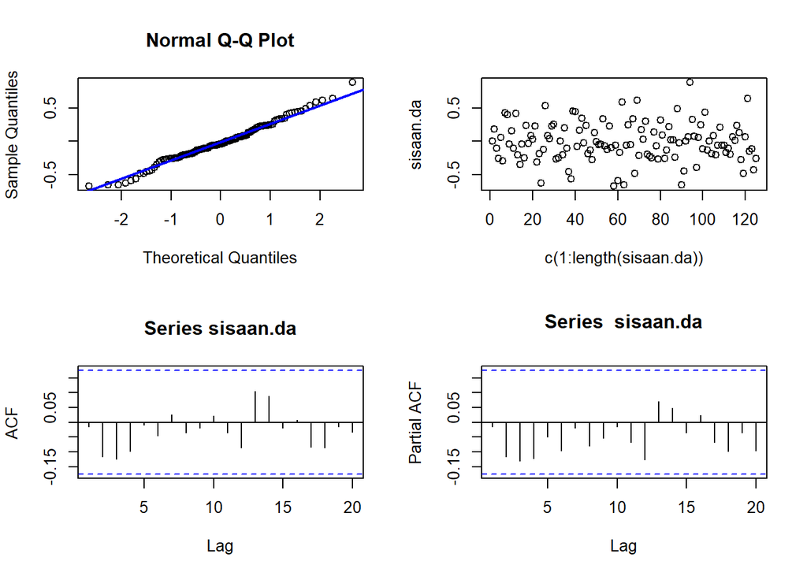

```r
sisaan.da <- model1.da$residuals
par(mfrow=c(2,2))
qqnorm(sisaan.da)
qqline(sisaan.da, col = "blue", lwd = 2)
plot(c(1:length(sisaan.da)),sisaan.da)
acf(sisaan.da)
pacf(sisaan.da)
```

```r
ks.test(sisaan.da,"pnorm")
```

```
##
##  Asymptotic one-sample Kolmogorov-Smirnov test
##
## data:  sisaan.da
## D = 0.27714, p-value = 9.164e-09
## alternative hypothesis: two-sided
```

karena p-value < 0.05 maka sisaan tidak menyebar normal.

#### Sisaan saling bebas

```r
Box.test(sisaan.da, type = "Ljung")
```

```
##
##  Box-Ljung test
##
## data:  sisaan.da
## X-squared = 0.025837, df = 1, p-value = 0.8723
```

karena p-value > 0.05 maka sisaan saling bebas.

#### Sisaan Homogen

```r
Box.test((sisaan.da)^2, type = "Ljung")
```

```
##
##  Box-Ljung test
##
## data:  (sisaan.da)^2
## X-squared = 0.0093908, df = 1, p-value = 0.9228
```

karena p-value > 0.05 maka sisaan homogen.

#### Nilai harapan sisaan sama dengan nol

```r
t.test(sisaan.da, mu = 0, conf.level = 0.95)
```

```
##
##  One Sample t-test
##
## data:  sisaan.da
## t = -0.63807, df = 124, p-value = 0.5246
## alternative hypothesis: true mean is not equal to 0
## 95 percent confidence interval:
##  -0.06762600  0.03465348
## sample estimates:
##   mean of x
## -0.01648626
```

karena p-value > 0.05 maka nilai harapan sisaan sama dengan nol.

## Peramalan

Peramalan dilakukan menggunakan fungsi forecast() . Contoh peramalan berikut ini dilakukan untuk 12 hari ke depan.

```r
ramalan.da <- forecast::forecast(model1.da, h = 12)
ramalan.da
```

```
##     Point Forecast      Lo 80     Hi 80      Lo 95     Hi 95
## 126    0.009668651 -0.3656641 0.3850014 -0.5643533 0.5836906
## 127   -0.002110948 -0.3777207 0.3734988 -0.5765565 0.5723346
## 128   -0.001555175 -0.3771722 0.3740618 -0.5760118 0.5729015
## 129   -0.001581397 -0.3771981 0.3740353 -0.5760376 0.5728748
## 130   -0.001580160 -0.3771969 0.3740366 -0.5760364 0.5728761
## 131   -0.001580218 -0.3771969 0.3740365 -0.5760364 0.5728760
## 132   -0.001580215 -0.3771969 0.3740365 -0.5760364 0.5728760
## 133   -0.001580216 -0.3771969 0.3740365 -0.5760364 0.5728760
## 134   -0.001580216 -0.3771969 0.3740365 -0.5760364 0.5728760
## 135   -0.001580216 -0.3771969 0.3740365 -0.5760364 0.5728760
## 136   -0.001580216 -0.3771969 0.3740365 -0.5760364 0.5728760
## 137   -0.001580216 -0.3771969 0.3740365 -0.5760364 0.5728760
```

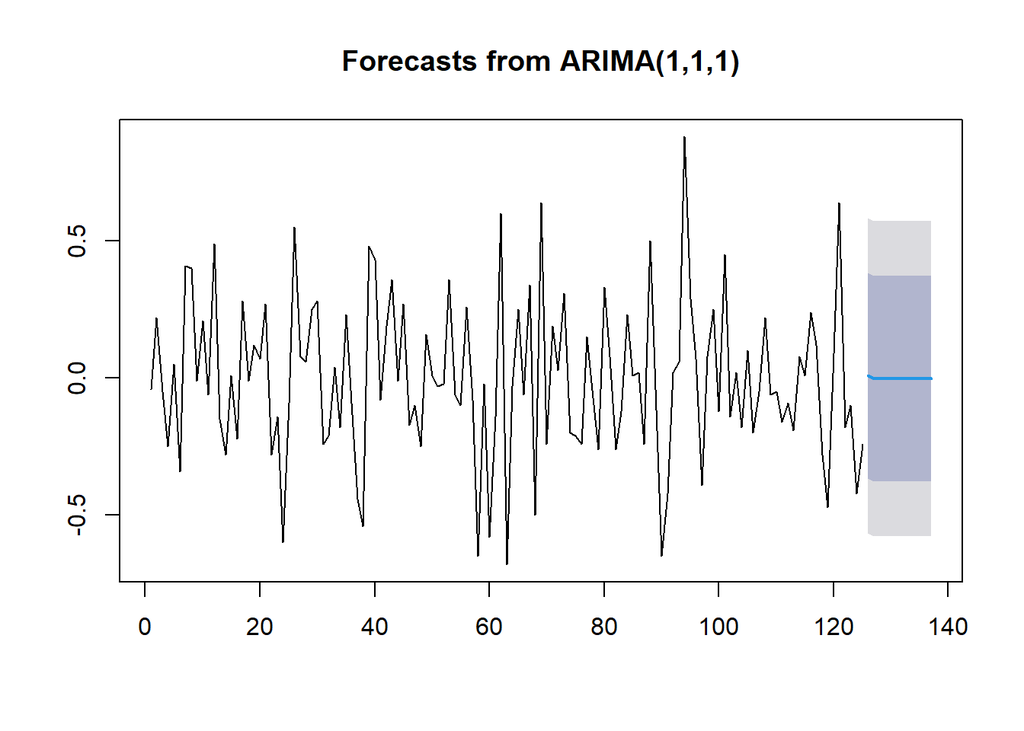

```r
data.ramalan.da <- ramalan.da$mean
plot(ramalan.da)
```

Berdasarkan hasil plot ramalan di atas, dapat dilihat bahwa ramalan ARIMA(1,1,1) cenderung stabil hingga akhir periode. Selanjutnya, dapat dicari nilai akurasi antara hasil ramalan dengan data uji sebagai berikut.

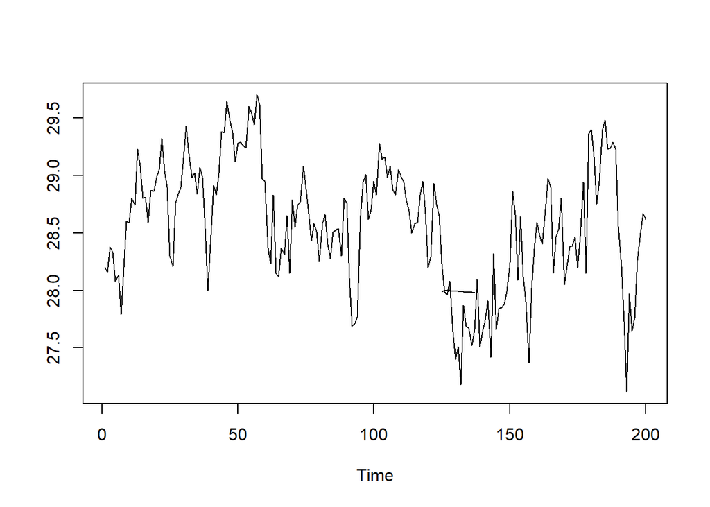

```r
data.train <- data$temp
data.train <- ts(data.train)
pt_1 <- data.train[126] #nilai akhir data latih
hasil.forc.Diff <- data.ramalan.da
hasil <- diffinv(hasil.forc.Diff, differences = 1) + pt_1
#has.1 sama hasilnta dengan: cumsum(c(pt_1,hasil.forc.Diff))
ts.plot(data.train, hasil)
```

```r
perbandingan.da<-matrix(data=c(head(data.test, n=12), hasil[-1]),
                     nrow = 12, ncol = 2)
colnames(perbandingan.da)<-c("Aktual","Hasil Forecast")
perbandingan.da
```

```
##       Aktual Hasil Forecast
##  [1,]  27.96       27.99967
##  [2,]  28.08       27.99756
##  [3,]  27.64       27.99600
##  [4,]  27.40       27.99442
##  [5,]  27.51       27.99284
##  [6,]  27.18       27.99126
##  [7,]  27.87       27.98968
##  [8,]  27.69       27.98810
##  [9,]  27.67       27.98652
## [10,]  27.52       27.98494
## [11,]  27.66       27.98336
## [12,]  28.10       27.98178
```

```r
accuracy(ts(hasil[-1]), head(data.test, n=12))
```

```
##                 ME      RMSE       MAE       MPE     MAPE
## Test set -0.300511 0.3997711 0.3339548 -1.094443 1.213495
```